# Homework 3

Author

PSTAT 134/234

## Homework 3

[figure not shown]

Star Trek ships.

For this homework assignment, we’ll be working with a dataset called [Spaceship Titanic](https://www.kaggle.com/competitions/spaceship-titanic/overview). It is a simulated dataset used for a popular Kaggle competition, intended to be similar to the very famous Titanic dataset. The premise of the Spaceship Titanic data is that it is currently the year 2912. You have received a transmission from four lightyears away, sent by the Spaceship Titanic, which was launched a month ago.

The Titanic set out with about 13,000 passengers who were emigrating from our solar system to three newly habitable exoplanets. However, it collided with a spacetime anomaly hidden in a dust cloud, and as a result, although the ship remained intact, half of the passengers on board were transported to an alternate dimension. Your challenge is to predict which passengers were transported, using records recovered from the spaceship’s damaged computer system.

The dataset is provided in `/data`, along with a codebook describing each variable. You should read the dataset into your preferred coding language (R or Python) and familiarize yourself with each variable.

We will use this dataset for the purposes of practicing our data visualization and feature engineering skills.

### Exercise 1

Which variables have missing values? What percentage of these variables is missing? What percentage of the overall dataset is missing?

```r
data <- read.csv("data/spaceship_titanic.csv")
colSums(is.na(data))
```

```
 PassengerId   HomePlanet    CryoSleep        Cabin  Destination          Age
           0            0            0            0            0          179
         VIP  RoomService    FoodCourt ShoppingMall          Spa       VRDeck
           0          181          183          208          183          188
        Name  Transported
           0            0
```

```r
colMeans(is.na(data)) * 100
```

```
 PassengerId   HomePlanet    CryoSleep        Cabin  Destination          Age
    0.000000     0.000000     0.000000     0.000000     0.000000     2.059128
         VIP  RoomService    FoodCourt ShoppingMall          Spa       VRDeck
    0.000000     2.082135     2.105142     2.392730     2.105142     2.162660
        Name  Transported
    0.000000     0.000000
```

```r
mean(is.na(data)) * 100
```

```
[1] 0.921924
```

### Exercise 2

Use mode imputation to fill in any missing values of `home_planet`, `cryo_sleep`, `destination`, and `vip`. Drop any observations with a missing value of `cabin` (there are too many possible values).

```r
# matching the variable capitalization in the question
library(janitor)
library(tidyverse)
data <- data %>%
  clean_names()

# i used ai for this mode function since I coulnd't find any code on mode imputation in the labs
get_mode <- function(x) {
  ux <- unique(na.omit(x))
  ux[which.max(tabulate(match(x, ux)))]
}

# Mode imputation
data <- data %>%
  mutate(home_planet = replace_na(home_planet, get_mode(home_planet)),
                         cryo_sleep = replace_na(cryo_sleep, get_mode(cryo_sleep)),
                         destination = replace_na(destination, get_mode(destination)),
                         vip = replace_na(vip, get_mode(vip))
                         )

# Drop obseravations with missing "cabin" values
data <- data %>% drop_na(cabin)
```

Use median imputation to fill in any missing values of `age`. Rather than imputing with the overall mean of `age`, impute with the median age of the corresponding `vip` group. (For example, if someone who is a VIP is missing their age, replace their missing age value with the median age of all passengers who are **also** VIPs).

```r
data <- data %>%
  group_by(vip) %>%
  mutate(age = replace_na(age, median(age, na.rm = TRUE))) %>%
  ungroup()
```

For passengers missing any of the expenditure variables (`room_service`, `food_court`, `shopping_mall`, `spa`, or `vr_deck`), handle them in this way:

- If all their observed expenditure values are $0$, **or** if they are in cryo-sleep, replace their missing value(s) with $0$.
- For the remaining missing expenditure values, use mean imputation.

```r
exp_vars <- c("room_service", "food_court", "shopping_mall", "spa", "vr_deck")

data <- data %>%
  rowwise() %>%
  mutate(
    obs_exp = list(na.omit(c_across(all_of(exp_vars)))),
    all_zero_exp = length(obs_exp) > 0 && all(obs_exp == 0)
  ) %>%
  ungroup() %>%
  mutate(across(all_of(exp_vars), ~ ifelse(is.na(.) & (all_zero_exp | cryo_sleep == TRUE), 0, .))) %>%
  mutate(across(all_of(exp_vars), ~ replace_na(., mean(., na.rm = TRUE)))) %>%
  select(-obs_exp, -all_zero_exp)
```

### Exercise 3

What are the proportions of both levels of the outcome variable, `transported`, in the dataset?

```r
prop.table(table(data$transported))
```

```
    False      True
0.4963764 0.5036236
```

### Exercise 4

Make proportion stacked bar charts of each of the following. Describe what patterns, if any, you observe.

1. `home_planet` and `transported`
2. `cryo_sleep` and `transported`
3. `destination` and `transported`
4. `vip` and `transported`

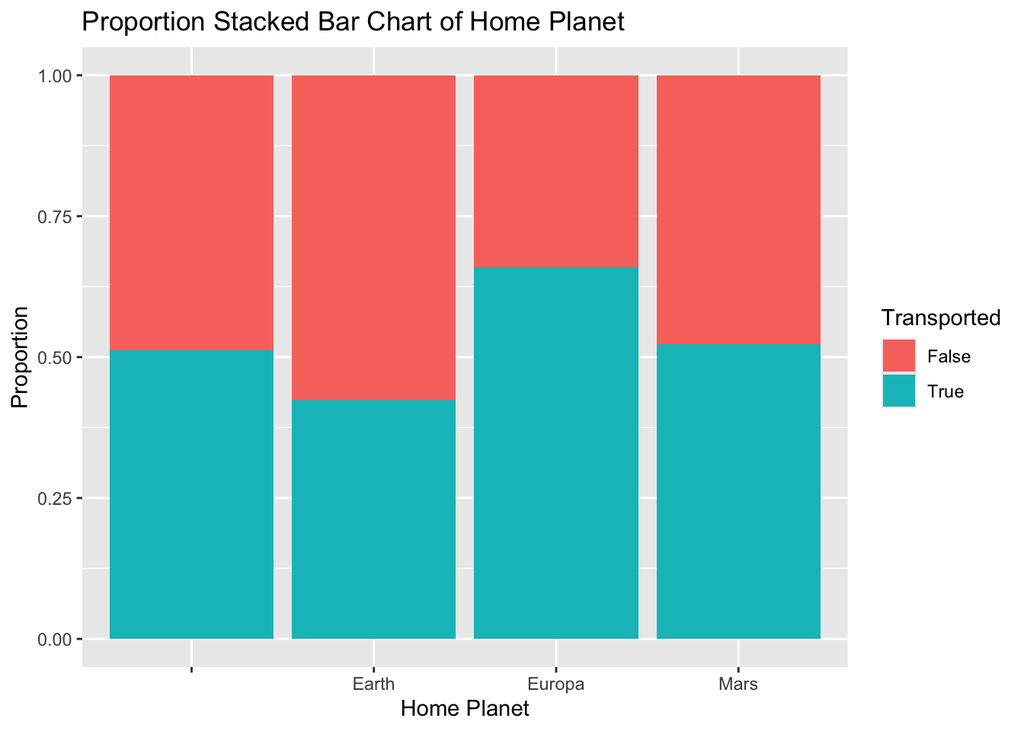

```r
ggplot(data, aes(x = home_planet, fill = factor(transported))) +
  geom_bar(position = "fill") +
  labs(title = "Proportion Stacked Bar Chart of Home Planet", x = "Home Planet", y = "Proportion", fill = "Transported")
```

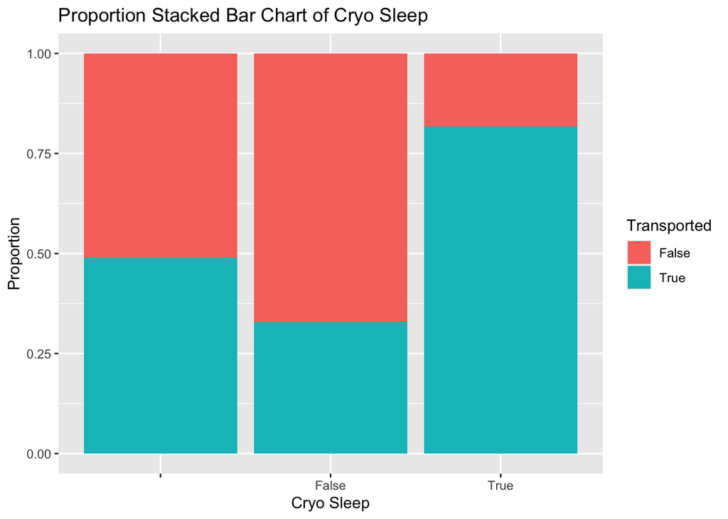

```r
ggplot(data, aes(x = cryo_sleep, fill = factor(transported))) +
  geom_bar(position = "fill") +
  labs(title = "Proportion Stacked Bar Chart of Cryo Sleep", x = "Cryo Sleep", y = "Proportion", fill = "Transported")
```

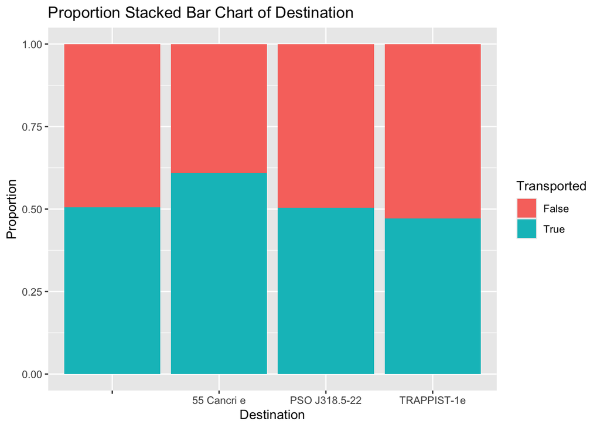

```r
ggplot(data, aes(x = destination, fill = factor(transported))) +
  geom_bar(position = "fill") +
  labs(title = "Proportion Stacked Bar Chart of Destination", x = "Destination", y = "Proportion", fill = "Transported")
```

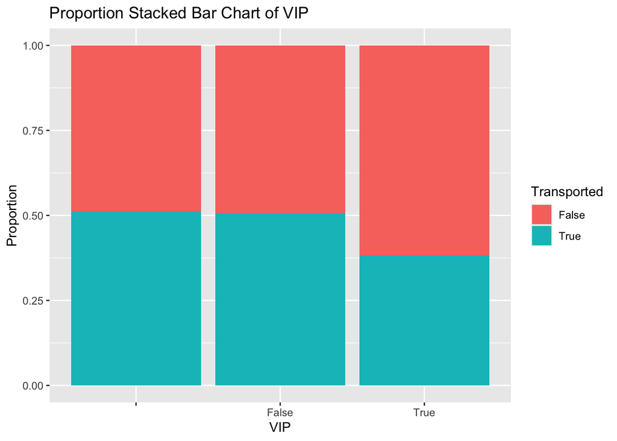

```r
ggplot(data, aes(x = vip, fill = factor(transported))) +
  geom_bar(position = "fill") +
  labs(title = "Proportion Stacked Bar Chart of VIP", x = "VIP", y = "Proportion", fill = "Transported")
```

### Exercise 5

Using box plots, density curves, histograms, dot plots, or violin plots, compare the distributions of the following and describe what patterns you observe, if any.

1. `age` across levels of `transported`
2. `room_service` across levels of `transported`
3. `spa` across levels of `transported`
4. `vr_deck` across levels of `transported`

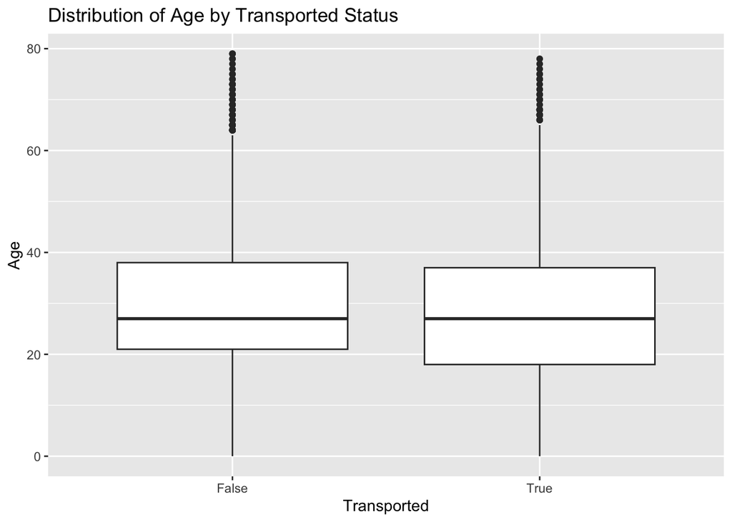

```r
ggplot(data, aes(x = factor(transported), y = age)) +
  geom_boxplot() +
  labs(title = "Distribution of Age by Transported Status", x = "Transported", y = "Age")
```

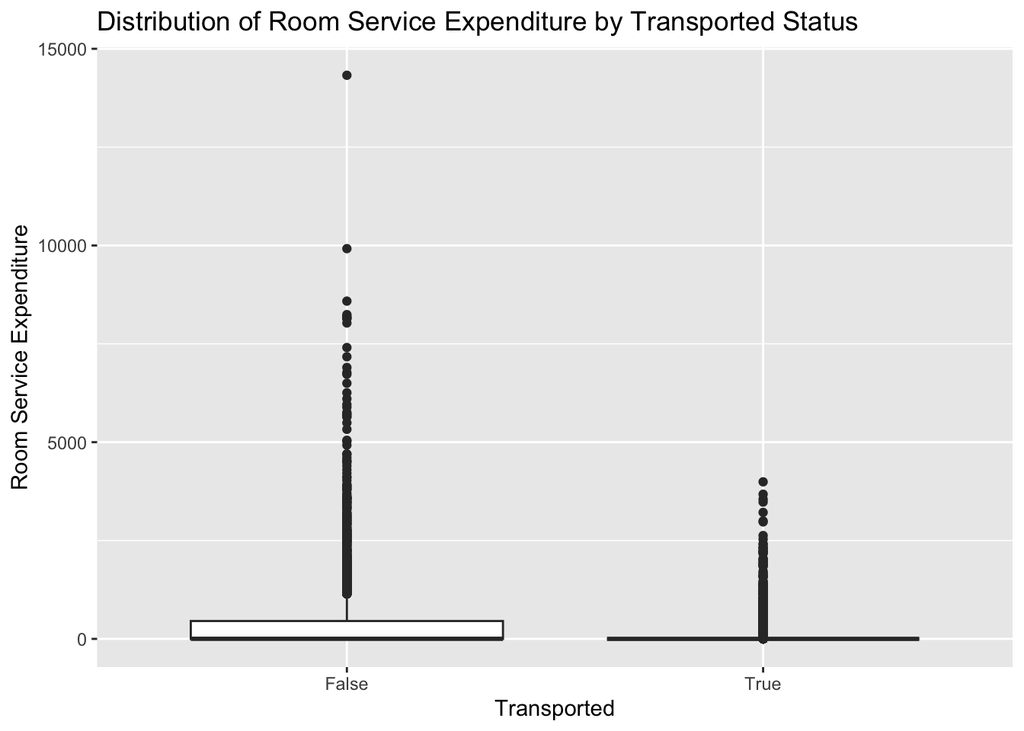

```r
ggplot(data, aes(x = factor(transported), y = room_service)) +
  geom_boxplot() +
  labs(title = "Distribution of Room Service Expenditure by Transported Status", x = "Transported", y = "Room Service Expenditure")
```

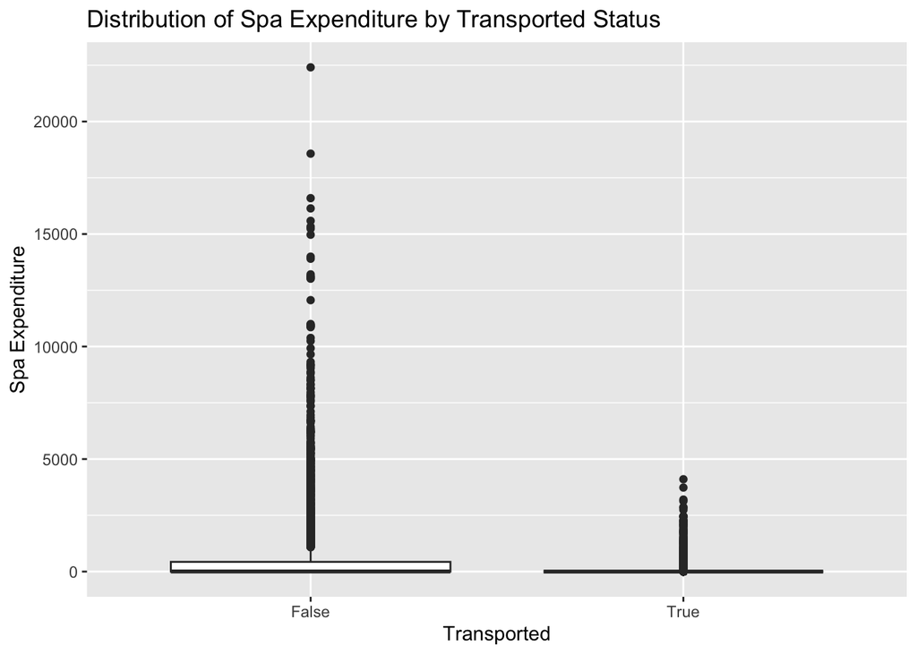

```r
ggplot(data, aes(x = factor(transported), y = spa)) +
  geom_boxplot() +
  labs(title = "Distribution of Spa Expenditure by Transported Status", x = "Transported", y = "Spa Expenditure")
```

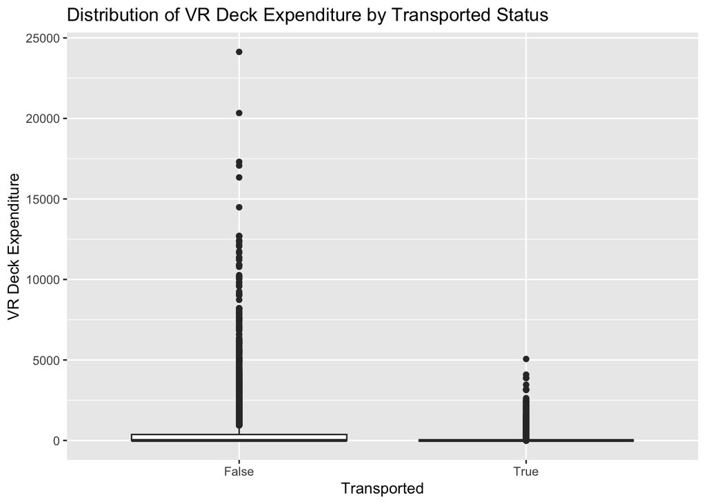

```r
ggplot(data, aes(x = factor(transported), y = vr_deck)) +
  geom_boxplot() +
  labs(title = "Distribution of VR Deck Expenditure by Transported Status", x = "Transported", y = "VR Deck Expenditure")
```

Age is similarly distributed between both groups. The expenditure variables are right skewed, and many of the passnegers who were transported spent exactly $0 on these different expenditures.

### Exercise 6

Make a correlogram of the continuous variables in the dataset. What do you observe?

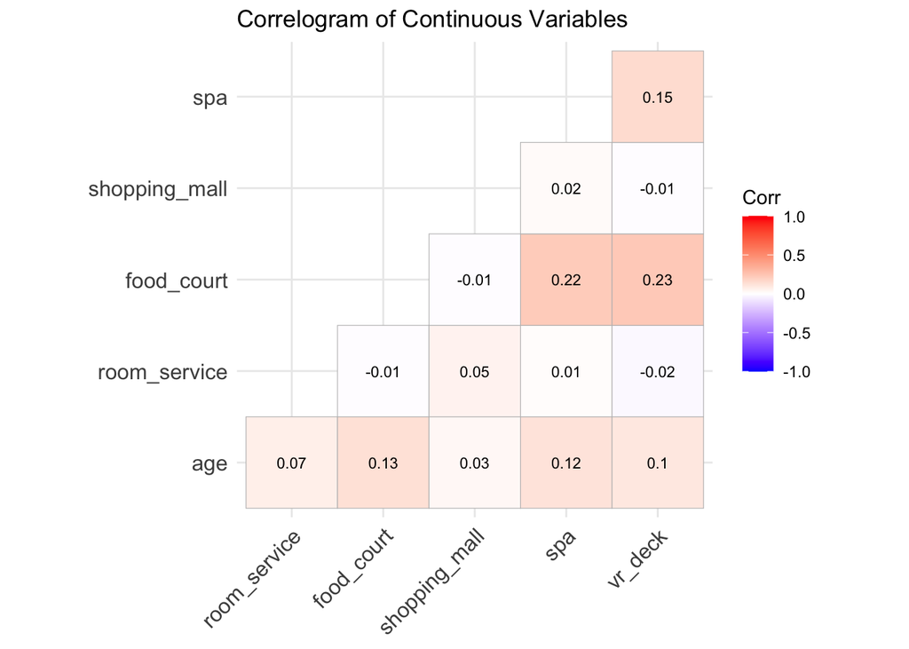

```r
library(ggcorrplot)

cont_vars <- data %>%
  select(age, room_service, food_court, shopping_mall, spa, vr_deck)

corr_matrix <- cor(cont_vars)

ggcorrplot(corr_matrix, type = "lower", lab = TRUE, lab_size = 3, title = "Correlogram of Continuous Variables")
```

Most of the variables are not strongly correlated, with the strongest correlations being spa and food_court as well as vr_deck and food_court

### Exercise 7

Use binning to divide the feature `age` into six groups: ages 0-12, 13-17, 18-25, 26-30, 31-50, and 51+.

```r
data <- data %>%
  mutate(age = cut(age, breaks = c(-Inf, 12, 17, 25, 30, 50, Inf),
                   labels = c("0-12", "13-17", "18-25", "26-30", "31-50", "51+")))
```

### Exercise 8

For the expenditure variables, do the following:

- Create a new feature that consists of the total expenditure across all five amenities;
- Create a binary feature to flag passengers who did not spend anything (a total expenditure of 0);
- Log-transform the total expenditure to reduce skew.

```r
data <- data %>%
  mutate(
    total_expenditure = room_service + food_court + shopping_mall + spa + vr_deck,
    zero_expenditure_flag = ifelse(total_expenditure == 0, 1, 0),
    log_total_expenditure = log(total_expenditure + 1)
  )
```

### Exercise 9

Using the `passenger_id` column, create a new binary-coded feature that represents whether a passenger was traveling alone or not. Make a proportion stacked bar chart of this feature and `transported`. What do you observe?

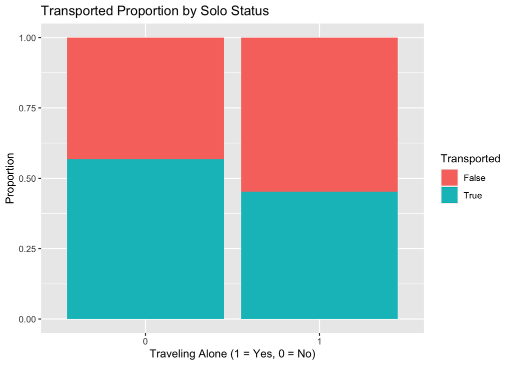

```r
# I used ai to help me separate the passnger id into the group and the number
data <- data %>%
  separate(passenger_id, into = c("group", "num_in_group"), sep = "_", remove = FALSE) %>%
  group_by(group) %>%
  mutate(solo = ifelse(n() == 1, 1, 0)) %>%
  ungroup()

ggplot(data, aes(x = factor(solo), fill = factor(transported))) +
  geom_bar(position = "fill") +
  labs(title = "Transported Proportion by Solo Status",
       x = "Traveling Alone (1 = Yes, 0 = No)", y = "Proportion", fill = "Transported")
```

Passengers traveling with others had a higher likelihood of being transported than those traveling solo.

### Exercise 10

Using the `cabin` variable, extract:

1. Cabin deck (A, B, C, D, E, F, G, or T);
2. Cabin number (0 to 2000);
3. Cabin side (P or S).

Then do the following:

- Drop any observations with a cabin deck of T;
- Bin cabin number into groups of 300 (for example, 0 - 300, 301 - 600, 601- 900, etc.).

```r
data <- data %>%
  separate(cabin, into = c("cabin_deck", "cabin_num", "cabin_side"), sep = "/") %>%
  filter(cabin_deck != "T") %>%
  mutate(
    cabin_num = as.numeric(cabin_num),
    cabin_num_binned = cut(cabin_num,
                           breaks = seq(0, 2100, by = 300),
                           include.lowest = TRUE,
                           labels = c("0-300", "301-600", "601-900", "901-1200",
                                      "1201-1500", "1501-1800", "1801-2100"))
  )
```

### Exercise 11

Create a new data frame (or tibble) that retains the following features:

1. `home_planet`
2. cabin deck
3. cabin number (binned)
4. cabin side
5. `age` (binned)
6. total expenditures (log-transformed)
7. `cryo_sleep`
8. `destination`
9. whether the passenger was traveling alone (call this `solo`)

To those features, do the following:

- One-hot encode all categorical features
- Center and scale all continuous features

```r
# ai helped suggest this library to me to simplify the one-hot encoding.
library(fastDummies)

final_df <- data %>%
  select(home_planet, cabin_deck, cabin_num_binned, cabin_side, age,
         log_total_expenditure, cryo_sleep, destination, solo)

final_df_scaled <- final_df %>%
  mutate(log_total_expenditure = as.vector(scale(log_total_expenditure)))

final_df_processed <- dummy_cols(final_df_scaled,
                                 remove_first_dummy = FALSE,
                                 remove_selected_columns = TRUE)
```

### Exercise 12

Write up your analyses thus far in one or two paragraphs. Describe what you have learned about the passengers on the Spaceship Titanic. Describe the relationships you observed between variables. Which features do you think may be the best predictors of transported status? Why or why not?

Cryo sleep is likely the strongest predictor. The bar charts in exercise 4 show a significant difference in transport rates between awake and sleeping passengers. Perhaps the anomaly specifically affected the areas where cryo-sleep pods were located. Anothe explanation could be that awake passengers were in public areas that were affected differently. Expenditures can be used as a proxy for whether somebody was in cryo sleep (because all sleeping passengers spend 0), so this makes it a good candidate for prediction transported status as well.